# Bellwether Counties, 1960-2024

Why a county that always picks the winner predicts nothing

Democracy’s Data

Last updated September 13, 2026 at 10:53a EDT

On 13 November 2020, nine days after the election was called, the *Wall Street Journal* published a list of nineteen counties. Each had voted for the winner of every presidential election since 1980, ten in a row without a miss. The article’s subject was that almost all of them had just failed at once.[^1]

The genre returns every four years. Pundits hunt for bellwether counties, places whose vote matches the national outcome election after election, and read them as barometers of the country. The *New York Times* ran ten of them a month before the 2020 election;[^2] the *Washington Post* profiled Vigo County, Indiana. The counties are real, the records are real, and the arithmetic is checkable.

So check it: does a perfect record predict anything? Anyone deciding how much weight to give the next bellwether story can compute the answer, and this brief does. A perfect record turns out to be mostly luck, and when the nineteen failed, they failed together, for one reason.

## The test

The claim worth testing is predictive, not historical: that a county which matched the last ten winners tells you something about the eleventh. Two tests answer it. First, count the counties with perfect records and compare the count against what pure chance would produce, since among 3,081 counties flipping like coins, some perfect records are guaranteed. Second, grade the *Journal*’s nineteen out of sample — on elections that happened after the list was made: they were selected in November 2020 on a record running through 2016, and two elections have happened since.

The data is county-level presidential returns, 1960 through 2024. No federal agency counts votes, so every long county series is a private act of assembly; the returns chapter explains what a certified return is and what a compilation of returns can bear. The long series here is the replication archive Carlos Algara and Sharif Amlani published with their 2021 *Electoral Studies* paper,[^3] carrying county presidential returns from 1868 to 2020, openly licensed on Harvard Dataverse, the research archive Harvard runs for data that accompanies published work. It is itself built from files sold by CQ Press, a political publisher, and held by ICPSR, the University of Michigan’s social-science data archive — a compilation of compilations, none of which any government produced. The 2024 column comes from a compilation Tony McGovern maintains on GitHub, checked against twenty-six states’ own certified publications.

## The data

`county_winners.csv` holds one row per county: `fips`, `county`, `state`, and one column per election, `y1960` through `y2024`, each holding a D or an R for the party that carried the county. Nothing else is in it — no demographics, no turnout, no margins. `national.csv` names the party of the national winner each year, twice: `ec` for the Electoral College winner and `pv` for the popular-vote winner, because in 2000 and 2016 those were different men.

One thing about the file has to be done by hand. Harvard Dataverse serves the archive only to a browser, so it is downloaded once through one, at the address in the Sources. A file that arrives by hand is a file nobody else has audited, which is why it is checked here against two other compilations:

| Check | Result |
| --- | --- |
| Against MEDSL’s independently compiled county returns, 2000-2016 | 15,562 county-elections compared, 12 disagreements about the winner (0.077%) |
| Against 26 states’ own certified 2024 returns, from county-returns/ | 1,909 counties compared, every vote total identical |
| Reproducing the Wall Street Journal’s list from scratch | searched for counties perfect over 1980-2016: found 19, and they are the same 19 |

The 12 winner disagreements with the independent compilation of MEDSL, the MIT Election Data and Science Lab, are decisions about what counts as one county, and one typo. New York’s fusion voting lets one nominee appear on several party lines, Kansas City reports separately from its county, and one file transposes a pair of totals. None of them touches a county with a good record, and `crosscheck.csv` spells out each one’s `reason`.

Here is one row, spread out — Vigo County, Indiana, the most written-about bellwether in the country:

| Field | Value |
| --- | --- |
| FIPS code | 18167 |
| county | Vigo |
| state | IN |
| carried by, 1960 through 1976 | D D R R D |
| 1980 through 1996 | R R R D D |
| 2000 through 2016 | R R D D R |
| 2020 | R |
| 2024 | R |

> **Before you read on, write a number down.** Nineteen counties, each with a perfect ten-election record when the *Journal* published its list. Two elections have been held since. **How many of the nineteen still have a perfect record?** Commit to a count before you look — and, for the harder version of the question, commit also to whether the ones that failed did so in the *same* election as each other.

## What it says about democracy

Start with the counting argument. Suppose every county were a fair coin, landing on the national winner half the time and independently of the others. Then the number with a perfect record over the last $k$ elections would be 3,081 divided by $2^k$. Over the last three, that is 3,081 divided by 2 × 2 × 2 = 8, about 385 counties with a perfect record on luck alone.

| Elections | Perfect records expected from coin-flipping | Perfect records observed |
| --- | --- | --- |
| the last 3 (2016-2024) | 385 | 32 |
| the last 5 (2008-2024) | 96 | 14 |
| the last 7 (2000-2024) | 24 | 1 |
| the last 10 (1988-2024) | 3.0 | 0 |
| the last 13 (1976-2024) | 0.38 | 0 |
| the last 17 (1960-2024) | 0.02 | 0 |

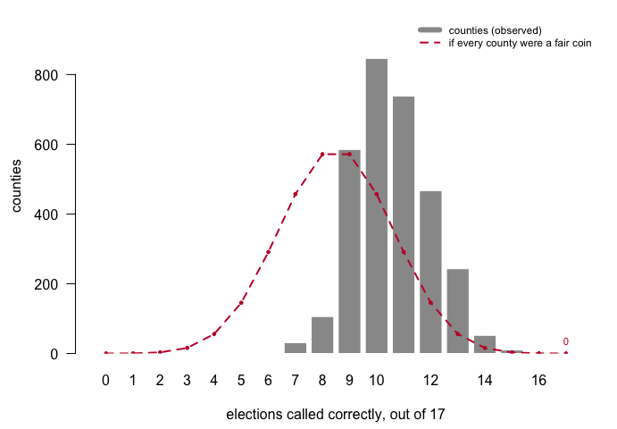

Hover a bar.

Now the out-of-sample test.

| County | Record 1980-2016 | 2020 | 2024 | Still perfect |
| --- | --- | --- | --- | --- |
| Bremer, IA | 10 of 10 | R | R | no |
| Warren, IL | 10 of 10 | R | R | no |
| Vigo, IN | 10 of 10 | R | R | no |
| Washington, ME | 10 of 10 | R | R | no |
| Shiawassee, MI | 10 of 10 | R | R | no |
| Van Buren, MI | 10 of 10 | R | R | no |
| Hidalgo, NM | 10 of 10 | R | R | no |
| Valencia, NM | 10 of 10 | R | R | no |
| Cortland, NY | 10 of 10 | R | R | no |
| Otsego, NY | 10 of 10 | R | R | no |
| Ottawa, OH | 10 of 10 | R | R | no |
| Wood, OH | 10 of 10 | R | R | no |
| Westmoreland, VA | 10 of 10 | R | R | no |
| Essex, VT | 10 of 10 | R | R | no |
| Clallam, WA | 10 of 10 | D | D | no |
| Juneau, WI | 10 of 10 | R | R | no |
| Marquette, WI | 10 of 10 | R | R | no |
| Richland, WI | 10 of 10 | R | R | no |
| Sawyer, WI | 10 of 10 | R | R | no |

The national winner in 2020 was a Democrat. **18 of the 19 voted Republican**, and their records ended that night. One survived: Clallam, WA, which voted for Biden as the country did. Then the national winner in 2024 was a Republican, and Clallam, WA voted Democratic. **0 of the nineteen survive.**

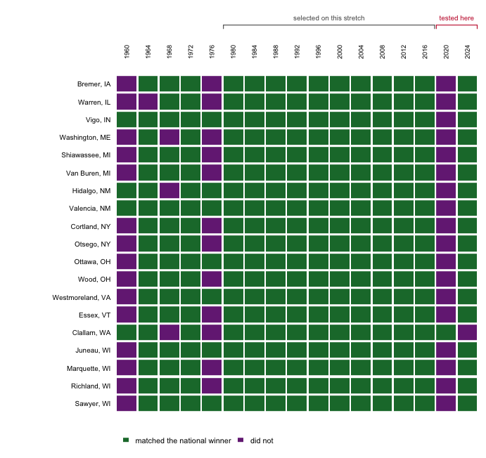

Hover any square.

Eighteen simultaneous failures is not eighteen separate surprises. Nineteen independent coins fail eighteen or more at once with probability 0.00004, about four in a hundred thousand, so the failures were not independent.

| Quantity | Value |
| --- | --- |
| Of the nineteen, the share that voted Republican in 2020 | 95% |
| Of all 3,081 counties, the share that voted Republican in 2020 | 83% |
| Probability 18 of 19 independent fair coins fail together | 0.00004 |

**95% of the nineteen voted Republican in 2020. So did 83% of every county in America.** The bellwethers did nothing unusual: they did what the typical American county did, which is what they had been doing all along. And in 2020 the typical county voted for the loser of the national popular vote, because most counties are small and rural and the national majority no longer lives in them.

A bellwether, in other words, is not a county that tracks the nation. It is a county whose partisan lean happens to sit near the tipping point of the elections you looked at — the fifty-fifty line the national outcome turned on. When the tipping point moves, they all fail together, because they were all the same bet.

The bet has also stopped paying for a mechanical reason: counties stopped changing their minds.

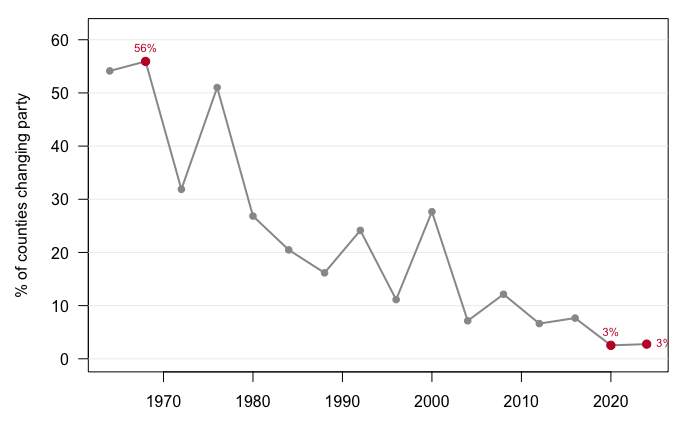

Hover a point.

**Figure 3. The share of counties voting differently than they had four years earlier.** In 1968, 56% of counties changed party; in 2024, 2.8% did. A county that never changes its mind cannot stay a bellwether, because sooner or later the nation changes its mind without it.

One last definition decides more than it seems to. The newspaper lists score counties against the Electoral College winner; Grofman and Chen argue the popular vote is the sensible standard, since a county is a sample of the country’s voters, not of its electors.[^4] In 2000 and 2016 the two standards name different winners.

| “the national winner” means | Elections won | Perfect records | Best record | Held by |
| --- | --- | --- | --- | --- |
| Electoral College winner | 8D / 9R | 0 | 16 | Vigo, IN; Blaine, MT; Valencia, NM |
| National popular-vote winner | 10D / 7R | 0 | 16 | Socorro, NM |

Under either definition the number of perfect records is **0**. But the near-misses are entirely different counties: the three that come within one election of perfection under the Electoral College share no members with the one that comes within one under the popular vote.

None of this is new. Tufte and Sun showed it in 1975 on the elections through 1968,[^5] and Grofman and Chen called it “flogging a dead horse” in 2023 and wrote the paper anyway, because the horse keeps getting up. It will be back in 2028.

## What this brief cannot tell you

**It cannot explain why any county votes as it does.** The file holds a D or an R per county per election and nothing else. Zimny-Schmitt and Harris (2020) found the bellwethers whiter, older, less educated and lower-income than the country,[^6] which alone sinks the miniature-America story, and nothing in this file could have told you it.

**A margin is not a winner.** A county carried by nine votes counts exactly as much as one carried by ninety thousand. That is the right unit for the bellwether question, which is asked in those terms, and the wrong unit for almost anything else.

**The long series is a compilation of compilations.** Its own sources are CQ Press and ICPSR. The 0.077% disagreement rate against MEDSL is a floor on the uncertainty rather than a measurement of it, because two compilations sharing a source agree more than either agrees with the truth.

**Counties are not stable objects.** Treating a county as the same thing in 1960 and 2024 is a convention, and the seventeen-election panel — the same counties followed through every election — quietly assumes that boundary changes did not matter.

## Extensions

None of these is answered above, and every one can be answered from the tables the Sources section hands over.

- `county_winners.csv` has one column per election, `y1960` through `y2024`. Count the counties that match the national winner in the last five columns alone, then work out how many such streaks chance would hand you.
- Take the counties with the best long records in `county_winners.csv` and read their `y2024` column. What did a nearly perfect record through 2020 actually predict?
- `crosscheck.csv` documents the places where two compilations disagree about a county’s winner, with the `reason` spelled out. Read one. How would you have caught it without somebody writing it down?
- `national.csv` records both the `ec` and `pv` winner each year. Find the years they differ, and work out what switching the standard does to a county that “picks the winner.”

Two stretch ideas point past the spreadsheet. Before 2028, write down the counties with the best current records, seal the list, and grade it in November 2028 — the prospective test no published bellwether list has ever run. And pull one bellwether county’s demographics from this book’s census chapters to see how much it actually resembles the country it supposedly predicts.

## Sources

**Data**

- Algara, Carlos and Sharif Amlani. 2021. *Replication Data for: Partisanship & Nationalization in American Elections: Evidence from Presidential, Senatorial, & Gubernatorial Elections in the U.S. Counties, 1872–2020.* Harvard Dataverse, V1. https://doi.org/10.7910/DVN/DGUMFI. File `dataverse_shareable_presidential_county_returns_1868_2020.Rdata`; used for 1960–2020. Downloaded through a browser from that page.
- MIT Election Data and Science Lab, *County Presidential Election Returns 2000–2016*, https://github.com/MEDSL/county-returns. Used only to check the file above.
- McGovern, Tony. *US County Level Election Results 08–24*, https://github.com/tonmcg/US_County_Level_Election_Results_08-24. Used for 2024, and checked against the twenty-six states’ certified returns assembled in the county-returns chapter.
- The party of the national winner in each election is not in any of these files. It is typed in by hand as two columns, one for the Electoral College and one for the popular vote.

**Academic literature**

- Grofman, Bernard and Haotian Chen. 2023. “Understanding the Factors that Affect the Incidence of Bellwether Counties: A Conditional Probability Model.” *Political Research Quarterly* 76(1): 119–126. doi:10.1177/10659129211057601; summarized at https://blogs.lse.ac.uk/usappblog/2022/03/23/bellwether-counties-are-mostly-a-matter-of-chance-and-are-now-poor-predictors-of-presidential-election-results/
- Amlani, Sharif and Carlos Algara. 2021. “Partisanship & Nationalization in American Elections: Evidence from Presidential, Senatorial & Gubernatorial Elections in the U.S. Counties, 1872–2020.” *Electoral Studies* 73: 102387. https://doi.org/10.1016/j.electstud.2021.102387
- Tufte, Edward R. and Richard A. Sun. 1975. “Are There Bellwether Electoral Districts?” *Public Opinion Quarterly* 39(1): 1–18. doi:10.1086/268193
- Zimny-Schmitt, Daniel and Michael Harris. 2020. “An Inquiry of Bellwether Counties in US Presidential Elections.” https://doi.org/10.2139/ssrn.3677602.

**Journalism this brief tests**

- McCormick, John. “Bellwether Counties Nearly Wiped Out by 2020 Election.” *Wall Street Journal*, 13 November 2020. The source of the nineteen.
- Wasserman, David. “The 10 Bellwether Counties That Show Trump Is in Serious Trouble.” *New York Times*, 6 October 2020.

**The data itself**

Every figure above is drawn from these tables. They are plain CSV, they open in a spreadsheet, and they are yours to take further.

`county_winners.csv`, `crosscheck.csv`, `national.csv`

Why this data cannot be fetched again

```
The core file behind this chapter comes from a source no assistant can
download for you -- though you can download it yourself, once, in a browser.

WHY NOT. The long series is Algara and Amlani's county-by-county
presidential returns, 1868-2020, published openly on Harvard Dataverse
at https://doi.org/10.7910/DVN/DGUMFI. Dataverse sits behind a bot
wall. A scripted request is not refused: it comes back with a
success-shaped status code and zero bytes attached, plus a challenge
that only a real browser's JavaScript can answer. A tool that did not
check would record the empty download as a win. The file is free and
openly licensed; the obstacle is plumbing, not permission.

WHAT EXISTS INSTEAD. Open the DOI above in a browser and download one
file by hand:
dataverse_shareable_presidential_county_returns_1868_2020.Rdata
(about 1.5 MB, in R's data format). Everything else arrives by
script: the 2024 county results from the tonmcg compilation on
GitHub, and MEDSL's independently compiled 2000-2016 county returns,
which exist here to cross-check the hand-carried file. There is no
free official substitute, because no federal agency counts votes
county by county.

WHAT YOU CAN STILL CHECK. If you obtain the file, these numbers say
whether you are holding the same object:
- the download is exactly 1,459,576 bytes
- kept to counties that are present, with a clear winner, in all
  seventeen elections from 1960 through 2024, the panel holds 3,081
  counties
- the two independent sources that overlap for 2000-2016 disagree
  about a county's winner in just twelve county-years
- the 2024 file from the compilation adds 3,160 county rows
```